# Working with SpidermiR package

Claudia Cava, Antonio Colaprico, Alex Graudenzi, Gloria Bertoli,Tiago C. Silva,Catharina Olsen,Houtan Noushmehr, Gianluca Bontempi, Giancarlo Mauri, Isabella Castiglioni

2017-09-04

# Introduction

Biological systems are composed of multiple layers of dynamic interaction networks. These networks can be decomposed, for example, into: co-expression, physical, co-localization, genetic, pathway, and shared protein domains.

GeneMania provides us with an enormous collection of data sets for interaction network studies (Warde-Farley D, Donaldson S, Comes O, Zuberi K, Badrawi R, and others 2010). The data can be accessed and downloaded from different database, using a web portal. But currently, there is not a R-package to query and download these data.

An important regulatory mechanism of these network data involves microRNAs (miRNAs). miRNAs are involved in various cellular functions, such as differentiation, proliferation, and tumourigenesis. However, our understanding of the processes regulated by miRNAs is currently limited and the integration of miRNA data in these networks provides a comprehensive genome-scale analysis of miRNA regulatory networks.Actually, GeneMania doesn’t integrate the information of miRNAs and their interactions in the network.

`SpidermiR` allows the user to query, prepare, download network data (e.g. from GeneMania), and to integrate this information with miRNA data with the possibility to analyze these downloaded data directly in one single R package. This techincal report gives a short overview of the essential `SpidermiR` methods and their application.

# Installation

To install use the code below.

```r
source("https://bioconductor.org/biocLite.R")
biocLite("SpidermiR")
```

# `SpidermiRquery`: Searching network

You can easily search GeneMania data using the `SpidermiRquery` function.

## `SpidermiRquery_species`: Searching by species

The user can query the species supported by GeneMania, using the function SpidermiRquery_species:

```r
org<-SpidermiRquery_species(species)
```

The list of species is shown below:

List of species

|  | tabOrgd[, 2] |
| --- | --- |
| 1 | Arabidopsis_thaliana |
| 2 | Caenorhabditis_elegans |
| 3 | Danio_rerio |
| 4 | Drosophila_melanogaster |
| 5 | Escherichia_coli |
| 6 | Homo_sapiens |
| 7 | Mus_musculus |
| 8 | Rattus_norvegicus |
| 9 | Saccharomyces_cerevisiae |

## `SpidermiRquery_networks_type`: Searching by network categories

The user can query the network types supported by GeneMania for a specific specie, using the function `SpidermiRquery_networks_type`. The user can select a specific specie using an index obtained by the function `SpidermiRquery_species` (e.g. organismID=org[6,] is the input for Homo_sapiens,organismID=org[9,] is the input for Saccharomyces cerevisiae )

```r
net_type<-SpidermiRquery_networks_type(organismID=org[9,])
```

The list of network categories in Saccharomyces cerevisiae is shown below:

```
## [1] "Co-localization"        "Predicted"
## [3] "Co-expression"          "Physical Interactions"
## [5] "Genetic Interactions"   "Shared protein domains"
## [7] "Other"
```

## `SpidermiRquery_spec_networks`: Searching by species, and network categories

You can filter the search by species using organism ID (above reported), and the network category. The network category can be filtered using the following parameters:

- **COexp** Co-expression
- **PHint** Physical_interactions
- **COloc** Co-localization
- **GENint** Genetic_interactions
- **PATH** Pathway
- **SHpd** Shared_protein_domains
- **pred** predicted

```r
net_shar_prot<-SpidermiRquery_spec_networks(organismID = org[9,],
                                    network = "SHpd")
```

The databases, which data are collected, are the output of this step. An example is shown below ( for Shared protein domains in Saccharomyces_cerevisiae data are collected in INTERPRO, and PFAM):

```
## [1] "http://genemania.org/data/current/Saccharomyces_cerevisiae/Shared_protein_domains.INTERPRO.txt"
## [2] "http://genemania.org/data/current/Saccharomyces_cerevisiae/Shared_protein_domains.PFAM.txt"
```

## `SpidermiRquery_disease`: Searching by miRNA-disease

The user can obtain a list of the diseases supported by SpidermiR, in order to focus only on miRNAs that have been already studied in a particular disease (retrieving data from miR2Disease (Jiang Q, Wang Y, Hao Y, Juan L, Teng M, Zhang X, Li M, Wang G, Liu Y. 2009)).

```r
disease<-SpidermiRquery_disease(diseaseID)
```

Currently, the list of diseases supported is:

```
##   [1] "kidney cancer"
##   [2] "hepatocellular carcinoma (HCC)"
##   [3] "lung cancer"
##   [4] "non-small cell lung cancer (NSCLC)"
##   [5] "ovarian cancer (OC)"
##   [6] "colorectal cancer"
##   [7] "head and neck squamous cell carcinoma (HNSCC)"
##   [8] "malignant melanoma"
##   [9] "Oral Squamous Cell Carcinoma (OSCC)"
##  [10] "prostate cancer"
##  [11] "Alzheimer's disease"
##  [12] "breast cancer"
##  [13] "cardiac hypertrophy"
##  [14] "pancreatic ductal adenocarcinoma (PDAC)"
##  [15] "uterine leiomyoma (ULM)"
```

[output cut: 137 more lines]

# `SpidermiRdownload`: Downloading network data

The user in this step can download the data, as previously queried.

## `SpidermiRdownload_net`: Download network

The user can download the data (previously queried) with `SpidermiRdownload_net`.

```r
out_net<-SpidermiRdownload_net(net_shar_prot)
```

```
## [1] "Downloading: http://genemania.org/data/current/Saccharomyces_cerevisiae/Shared_protein_domains.INTERPRO.txt ... reference n. 1 of 2"
## [1] "Downloading: http://genemania.org/data/current/Saccharomyces_cerevisiae/Shared_protein_domains.PFAM.txt ... reference n. 2 of 2"
```

The list of SpidermiRdownload_net is shown below:

```
## List of 2
##  $ :'data.frame':    47523 obs. of  3 variables:
##   ..$ Gene_A: chr [1:47523] "Q0050" "Q0050" "Q0055" "Q0050" ...
##   ..$ Gene_B: chr [1:47523] "Q0055" "Q0060" "Q0060" "Q0065" ...
##   ..$ Weight: num [1:47523] 0.39 0.09 0.15 0.09 0.15 0.23 0.1 0.17 0.18 0.18 ...
##  $ :'data.frame':    30228 obs. of  3 variables:
##   ..$ Gene_A: chr [1:30228] "Q0050" "Q0055" "Q0055" "Q0060" ...
##   ..$ Gene_B: chr [1:30228] "Q0055" "Q0060" "Q0065" "Q0065" ...
##   ..$ Weight: num [1:30228] 0.39 0.12 0.12 0.22 0.14 0.14 0.14 0.15 0.15 0.34 ...
```

## `SpidermiRdownload_miRNAprediction`: Downloading miRNA predicted data target

The user can download the predicted miRNA-gene from 4 databases:DIANA, Miranda, PicTar and TargetScan

```r
mirna<-c('hsa-miR-567','hsa-miR-566')
SpidermiRdownload_miRNAprediction(mirna_list=mirna)
```

## `SpidermiRdownload_miRNAvalidate`: Downloading miRNA validated data target

The user can download the validated miRNA-gene from: miRTAR and miRwalk (Jiang Q, Wang Y, Hao Y, Juan L, Teng M, Zhang X, Li M, Wang G, Liu Y. 2009) (Dweep H, Sticht C, Pandey P, Gretz N. 2011).

```r
list<-SpidermiRdownload_miRNAvalidate(validated)
```

## `SpidermiRdownload_miRNAextra_cir`:Download Extracellular Circulating microRNAs

The user can download extracellular circulating miRNAs from miRandola database

```r
list<-SpidermiRdownload_miRNAextra_cir(miRNAextra_cir)
```

## `SpidermiRdownload_pharmacomir`: Download Pharmaco-miR Verified Sets from PharmacomiR database

The user can download Pharmaco-miR Verified Sets from PharmacomiR database (Rukov J, Wilentzik R, Jaffe I, Vinther J, Shomron N. 2013).

```r
mir_pharmaco<-SpidermiRdownload_pharmacomir(pharmacomir=pharmacomir)
```

# `SpidermiRprepare`: Preparing the data

## `SpidermiRprepare_NET`: Prepare matrix of gene network with Ensembl Gene ID, and gene symbols

`SpidermiRprepare_NET` reads network data from `SpidermiRdownload_net` and enables user to prepare them for downstream analysis. In particular, it prepares matrix of gene network mapping Ensembl Gene ID to gene symbols. Gene symbols are needed to integrate miRNAdata.

```r
geneSymb_net<-SpidermiRprepare_NET(organismID = org[9,],
                                    data = out_net)
```

```
## [1] "Preprocessing of the network n. 1 of 2"
## [1] "Preprocessing of the network n. 2 of 2"
```

The network with gene symbols ID is shown below:

shared protein domain

| Gene_A | Gene_B | Weight | gene_symbolA | gene_symbolB |
| --- | --- | --- | --- | --- |
| Q0050 | Q0055 | 0.39 | AI1 | AI2 |
| Q0050 | Q0060 | 0.09 | AI1 | AI3 |
| Q0055 | Q0060 | 0.15 | AI2 | AI3 |
| Q0050 | Q0065 | 0.09 | AI1 | AI4 |
| Q0055 | Q0065 | 0.15 | AI2 | AI4 |

# `SpidermiRanalyze`: : Analyze data from network data

## `SpidermiRanalyze_mirna_network`: Integration of microRNA-target interactions.

The user in this step obtained a network matrix with miRNA-target interactions starting from a specific network. The user can focus on miRNAs that have been already linked to a particular disease or take all miRNAs. miRNA-gene interactions include data from validated or predicted studies. You can filter the search by disease. The miRNA network can be filtered by disease using the name of the disease, as obtained from `SpidermiRquery_disease`.

```r
miRNA_NET<-SpidermiRanalyze_mirna_network(data=geneSymb_net,disease="prostate cancer",miR_trg="val")
```

The list of miRNA network is shown below:

```
## 'data.frame':    70 obs. of  2 variables:
##  $ V1: chr  "hsa-miR-127" "hsa-miR-141" "hsa-miR-210" "hsa-miR-222" ...
##  $ V2: chr  "XBP1" "SIP1" "PIM1" "MMP1" ...
```

## `SpidermiRanalyze_mirna_gene_complnet`: Integration of microRNA-target complete interactions

The user in this step obtained a gene network matrix with miRNA-gene and gene-gene interaction. The user can focus on miRNAs that have been already linked to a particular disease or take all miRNAs. miRNA-gene interactions include data from validated or predicted studies. The miRNA network can be filtered by disease using the name of the disease, as obtained from `SpidermiRquery_disease`.

```r
miRNA_complNET<-SpidermiRanalyze_mirna_gene_complnet(data=geneSymb_net,disease="prostate cancer",miR_trg="val")
```

## `SpidermiRanalyze_mirnanet_pharm`: Integration of pharmacomiR in the network

The user in this step can integrate the pharmacomiR database in order to link miRNA and drug effect in a specific network.

```r
mir_pharmnet<-SpidermiRanalyze_mirnanet_pharm(mir_ph=mir_pharmaco,net=miRNA_NET)
```

## `SpidermiRanalyze_mirna_extra_cir`: Integration of Extracellular/Circulating miRNA

The user can select the extracellular/circulating miRNAs found in the obtained network. Extracellular/circulating miRNAs include data from mirandola database (Russo F, Di Bella S, Nigita G, Macca V, Lagana A, Giugno R, Pulvirenti A, Ferro A. 2012). The user using the following parameteres can specify the network type:

- **mT** to obtain a miRNA-gene interaction
- **mCT** to obtain a miRNA-gene-gene interaction.

```r
miRNA_NET_ext_circmT<-SpidermiRanalyze_mirna_extra_cir(data=miRNA_complNET,"mT")
```

```r
miRNA_NET_ext_circmCT<-SpidermiRanalyze_mirna_extra_cir(data=miRNA_complNET,"mCT")
```

## `SpidermiRanalyze_direct_net`: Searching by biomarkers of interest with direct interaction

Starting from a set of biomarkers of interest (BI), genes, miRNA or both, given by the user, this function finds sub-networks including all direct interactions involving at least one of the BI.

```r
biomark_of_interest<-c("hsa-miR-214","PTEN","FOXO1","hsa-miR-27a")

GIdirect_net<-SpidermiRanalyze_direct_net(data=miRNA_NET,BI=biomark_of_interest)
```

```
## [1] "hsa-miR-214 is not in the network or please check the correct name"
## [1] "PTEN is not in the network or please check the correct name"
## [1] "FOXO1 is not in the network or please check the correct name"
```

The data frame of `SpidermiRanalyze_direct_net`, GIdirect_net, is shown below:

```
## 'data.frame':    1 obs. of  2 variables:
##  $ V1: chr "hsa-miR-27a"
##  $ V2: chr "PEX7"
```

## `SpidermiRanalyze_direct_subnetwork`: Network composed by only the nodes in a set of biomarkers of interest

Starting from BI, this function finds sub-networks including all direct interactions involving only BI.

```r
subnet<-SpidermiRanalyze_direct_subnetwork(data=miRNA_NET,BI=biomark_of_interest)
```

## `SpidermiRanalyze_subnetwork_neigh`: Network composed by the nodes in the list of BI and all the edges among this brunch of nodes.

Starting from BI, this function finds sub-networks including all direct and indirect interactions involving at least one of BI.

```r
GIdirect_net_neigh<-SpidermiRanalyze_subnetwork_neigh(data=miRNA_NET,BI=biomark_of_interest)
```

## `SpidermiRanalyze_degree_centrality`: Ranking degree centrality genes

This function finds the number of direct neighbours of a BI and allows the selection of those BI with a number of direct neighbours higher than a selected cut-off.

```r
top10_cent_gene<-SpidermiRanalyze_degree_centrality(miRNA_NET,cut=10)
```

## `SpidermiRanalyze_Community_detection`: Find community detection

This function find the communities in the network, and describes them in terms of number of community elements (both genes and miRNAs). The function uses one of the algorithms currently implemented in (Csardi G, Nepusz T. 2006), selected by the user according to the user need.

The user can choose the algorithm in order to calculate the community structure:

- **EB** edge.betweenness.community
- **FC** fastgreedy.community
- **WC** walktrap.community
- **SC** spinglass.community
- **LE** leading.eigenvector.community
- **LP** label.propagation.community

```r
comm<-  SpidermiRanalyze_Community_detection(data=miRNA_NET,type="FC")
```

## `SpidermiRanalyze_Community_detection_net`: Community detection

Starting from one community to which some BI belong (the output of the previously described function) this function describes the community as network of elements (both genes and miRNAs).

```r
cd_net<-SpidermiRanalyze_Community_detection_net(data=miRNA_NET,comm_det=comm,size=1)
```

## `SpidermiRanalyze_Community_detection_bi`: Community detection from a set of biomarkers of interest

Starting from the community to which BI belong (the output of the previously described function), this function indicates if a set of BI is included within such community.

```r
gi=c("CF","ROCK1","KIT","CCND2")
mol<-SpidermiRanalyze_Community_detection_bi(data=comm,BI=gi)
```

## `SpidermiRanalyze_DEnetworkTCGA`: Integration with TCGA data in order to obtain a network of differentially expressed (DE) genes or miRNAs.

`SpidermiRanalyze_DEnetworkTCGA` integrates the information of differential analysis of TCGA data in the network. The final result will be a network with only DE genes or miRNAs depending whether the user chooses mRNA or miRNA TCGA data.

```r
miRNA_cN <-data.frame(gA=c('IGFL3','GABRA1'),gB=c('IGFL2','KRT13'),stringsAsFactors=FALSE)
tumour<-c("TCGA-E9-A1RD-01A","TCGA-E9-A1RC-01A")
normal<-c("TCGA-BH-A18P-11A","TCGA-BH-A18L-11A")
de_int<-SpidermiRanalyze_DEnetworkTCGA(data=miRNA_cN,
                                        TCGAmatrix=Data_CANCER_normUQ_filt,
                                        tumour,
                                        normal
                                       )
```

```
## ----------------------- DEA -------------------------------
```

```
## there are Cond1 type Normal in  2 samples
```

```
## there are Cond2 type Tumor in  2 samples
```

```
## there are  15243 features as miRNA or genes
```

```
## I Need about  2 seconds for this DEA. [Processing 30k elements /s]
```

```
## ----------------------- END DEA -------------------------------
```

```
## [1] "The number of differentially expressed genes between the two classes is  1303"
## [1] "The network containing DEGs with direct interactions consistes of   2  nodes and  1  edges "
```

# `SpidermiRvisualize`: To visualize the network

## `SpidermiRvisualize_mirnanet`: To Visualize the network.

The user can visualize a 3D representation of the network in different colours for miRNA, genes, and pharmaco. The user can manage the network directly moving the nodes and the edges, in order to interpret the results in the graphic way.

```r
library(networkD3)

SpidermiRvisualize_mirnanet(data=mir_pharmnet[sample(nrow(mir_pharmnet), 100), ] )
```

[interactive chart not shown]

## `SpidermiRvisualize_BI`: To Visualize the network from a set of BI.

Starting from a graphical representation of a network, the user can highlight with a different color specific BI.

```r
biomark_of_interest<-c("hsa-let-7b","MUC1","PEX7","hsa-miR-222")
SpidermiRvisualize_BI(data=mir_pharmnet[sample(nrow(mir_pharmnet), 100), ],BI=biomark_of_interest)
```

[interactive chart not shown]

## `SpidermiRvisualize_direction`: To visualize the network

```r
library(visNetwork)

SpidermiRvisualize_direction(data=mir_pharmnet[sample(nrow(mir_pharmnet), 100), ] )
```

[interactive chart not shown]

## `SpidermiRvisualize_plot_target`: Visualize the plot with miRNAs and the number of their targets in the network.

For each BI of a community, the user can visualize a plot showing the number of direct neighbours of such BI (the degree centrality of such BI).

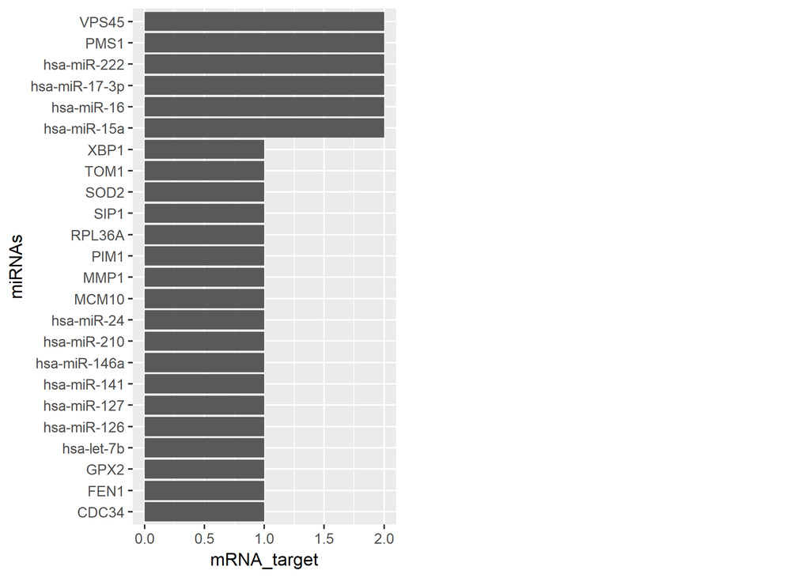

```r
SpidermiRvisualize_plot_target(data=miRNA_NET[1:15,])
```

## `SpidermiRvisualize_degree_dist`: plots the degree distribution of the network

This function plots the cumulative frequency distribution of degree centrality of a community.

```r
SpidermiRvisualize_degree_dist(data=miRNA_NET)
```

[figure not shown]

## `SpidermiRvisualize_adj_matrix`: plots the adjacency matrix of the network

It plots the adjacency matrix of the community, representing the degree of connections among the nodes.

```r
SpidermiRvisualize_adj_matrix(data=miRNA_NET[1:30,])
```

[figure not shown]

## `SpidermiRvisualize_3Dbarplot`: 3D barplot

It plots a summary representation of the networks with the number of edges, nodes and miRNAs.

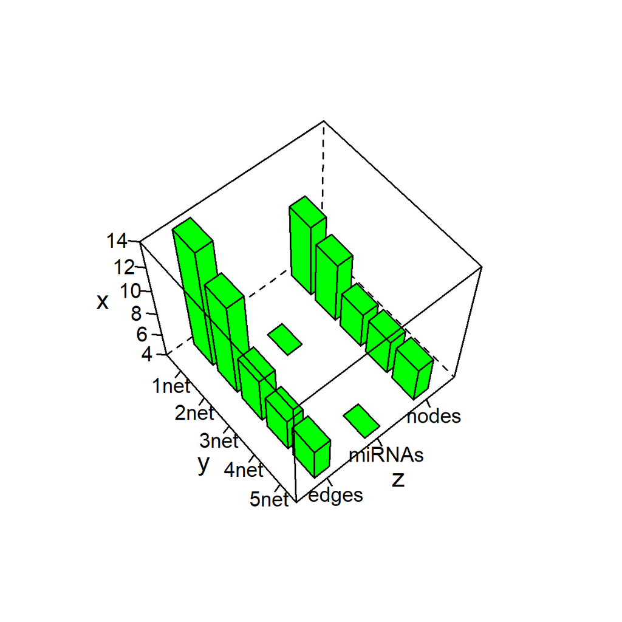

```r
SpidermiRvisualize_3Dbarplot(Edges_1net=1041003,Edges_2net=100016,Edges_3net=3008,Edges_4net=1493,Edges_5net=1598,NODES_1net=16502,NODES_2net=13338,NODES_3net=1429,NODES_4net=675,NODES_5net=712,nmiRNAs_1net=0,nmiRNAs_2net=74,nmiRNAs_3net=0,nmiRNAs_4net=0,nmiRNAs_5net=37)
```

# `Features databases SpidermiR`:

Features of databases integrated in `SpidermiR` are:

Features

| CATEGORY | EXTERNAL DATABASE | VERSION | LAST UPDATE | LINK |
| --- | --- | --- | --- | --- |
| Gene network | GeneMania | Current | 2016 | http://genemania.org/data/current/ |
| Validated miRNA-target | miRTAR | N/A | 2009 | http://watson.compbio.iupui.edu:8080/miR2Disease/download/miRtar.txt |
|  | miRwalk | miRwalk2 | 2015 | http://zmf.umm.uni-heidelberg.de/apps/zmf/mirwalk2/downloads/vtm/hsa-vtm-gene.rdata.zip |
|  | miRTarBase | miRTarBase 6.1 | N/A | http://mirtarbase.mbc.nctu.edu.tw/cache/download/6.1/miRTarBase_SE_WR.xls |
| Predicted miRNA-target | DIANA | DIANA- 5.0 | 2013 | https://bioconductor.org/packages/release/bioc/html/miRNAtap.html |
|  | Miranda | N/A | 2010 | https://bioconductor.org/packages/release/bioc/html/miRNAtap.html |
|  | PicTar | N/A | N/A | https://bioconductor.org/packages/release/bioc/html/miRNAtap.html |
|  | TargetScan | TargetScan7.1 | 2016 | https://bioconductor.org/packages/release/bioc/html/miRNAtap.html |
| Extracellular Circulating microRNAs | miRandola | miRandola v 02/2017 | 2017 | http://mirandola.iit.cnr.it/download/miRandola_version_02_2017.txt |
| miRNA-disease | miR2disease | N/A | 2009 | http://watson.compbio.iupui.edu:8080/miR2Disease/download/AllEntries.txt |
| Drug Associations | Pharmaco-miR | N/A | N/A | http://pharmaco-mir.org/home/download_VERSE_db/pharmacomir_VERSE_DB.csv |

# SpidermiR Downstream Analysis: Case Study Please see `SpidermiR:Application Examples` for more information.

## Case Study n.1: Role of miRNAs in shared protein domains network in Prostate Cancer

In this case study, we downloaded shared protein domains network in Homo Sapiens, using SpidermiRquery, SpidermiRprepare, and SpidermiRdownload.

Then, we focused on role of miRNAs in this network. We integrated miRNA information using SpidermiRanalyze. We obtained a big network, and in order to understand the underlying biological process of a set of biomarker of interest (e.g. from DEG) we performed an analysis to identify their neighbor biomarkers in the shared protein domains network. Please see `SpidermiR:Application Examples` for more information.

SpidermiRvisualize was used to see the results.

```r
a<-Case_Study1_loading_1_network(species)
b<-Case_Study1_loading_2_network(data=a)
c<-Case_Study1_loading_3_network(data=b,dataFilt=dataFilt,dataClin=dataClin)
d<-Case_Study1_loading_4_network(TERZA_NET=c)
```

## Case Study n.2: miRNAs regulating degree centrality genes in physical interactions network in breast cancer

We studied in this case study the relationships between miRNAs with higher centrality and their target proteins with higher centrality. Please see `SpidermiR:Application Examples` for more information.

```r
a2<-Case_Study2_loading_1_network(species)
b2<-Case_Study2_loading_2_network(data=a2)
c2<-Case_Study2_loading_3_network(sdas=a2,miRNA_NET=b2)
```

# References

Csardi G, Nepusz T. 2006. “The Igraph Software Package for Complex Network Research.”

Dweep H, Sticht C, Pandey P, Gretz N. 2011. “MiRWalk - Database Prediction of Possible MiRNA Binding Sites by ‘Walking’ the Genes of 3 Genomes.”

Jiang Q, Wang Y, Hao Y, Juan L, Teng M, Zhang X, Li M, Wang G, Liu Y. 2009. “MiR2Disease a Manually Curated Database for MicroRNA Deregulation in Human Disease.”

Rukov J, Wilentzik R, Jaffe I, Vinther J, Shomron N. 2013. “Pharmaco MiR Linking MicroRNAs and Drug Effects.”

Russo F, Di Bella S, Nigita G, Macca V, Lagana A, Giugno R, Pulvirenti A, Ferro A. 2012. “MiRandola Extracellular Circulating MicroRNAs Database.”

Warde-Farley D, Donaldson S, Comes O, Zuberi K, Badrawi R, and others. 2010. “The Gene Mania Prediction Server Biological Network Integration for Gene Prioritization and Predicting Gene Function.”